# Notebook Structure

1. Import necessary dependencies
2. Create data visualizations using Line chart
3. Create detailed line charts with multiple combination
4. How to interpret line chart

# 1. Import necessary dependencies

```python
# libraries & dataset
import matplotlib.pyplot as plt
import seaborn as sns
import pandas as pd

sns.set_theme(style="darkgrid")
```

```python
data = {
'Year': [2010, 2011, 2012, 2013, 2014, 2015, 2016, 2017, 2018, 2019],
'Sales': [100, 150, 200, 180, 250, 300, 280, 350, 400, 450],
'Expenses': [80, 120, 160, 140, 200, 240, 220, 280, 320, 360]
}
```

```python
df = pd.DataFrame(data)
df
```

|  | Year | Sales | Expenses |
| --- | --- | --- | --- |
| 0 | 2010 | 100 | 80 |
| 1 | 2011 | 150 | 120 |
| 2 | 2012 | 200 | 160 |
| 3 | 2013 | 180 | 140 |
| 4 | 2014 | 250 | 200 |
| 5 | 2015 | 300 | 240 |
| 6 | 2016 | 280 | 220 |
| 7 | 2017 | 350 | 280 |
| 8 | 2018 | 400 | 320 |
| 9 | 2019 | 450 | 360 |

```python
df.shape
```

```
(10, 3)
```

# 2. Create data visualizations using Line chart

### A. Create default line chart with "Sales" and "Expenses"

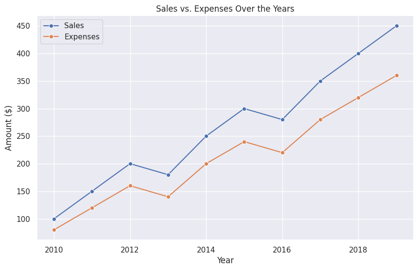

```python
plt.figure(figsize=(10, 6))  # Set the figure size for better readability
sns.lineplot(x='Year', y='Sales', data=df, marker='o', label='Sales')
sns.lineplot(x='Year', y='Expenses', data=df, marker='o', label='Expenses')
plt.title('Sales vs. Expenses Over the Years')
plt.xlabel('Year')
plt.ylabel('Amount ($)')  # Add a unit to the y-label for clarity
plt.legend()
plt.grid(True)
plt.show()
```

### B. Update the line chart with additional information

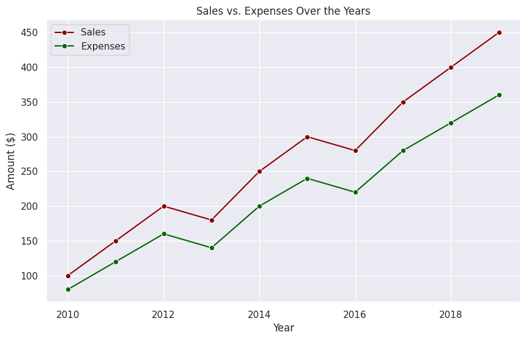

```python
plt.figure(figsize=(10, 6))  # Set the figure size for better readability
sns.lineplot(x='Year', y='Sales', data=df, marker='o', label='Sales', color='darkred')
sns.lineplot(x='Year', y='Expenses', data=df, marker='o', label='Expenses', color='darkgreen')
plt.title('Sales vs. Expenses Over the Years')
plt.xlabel('Year')
plt.ylabel('Amount ($)')  # Add a unit to the y-label for clarity
plt.legend()
plt.grid(True)
plt.show()
```

# 3. Create detailed line charts with multiple combination

### A. Create a dataset

```python
import numpy as np
# Create a dictionary with sample data
np.random.seed(42) # for reproducibility
data = {
'Year': range(2010, 2021),
'Sales': 100 + 10 * np.random.randn(11) + 15 * np.arange(11),
'Expenses': 50 + 5 * np.random.randn(11) + 10 * np.arange(11),
'Revenue': 200 + 8 * np.random.randn(11) + 12 * np.arange(11),
'Profit': 20 + 2 * np.random.randn(11) + 3 * np.arange(11),
'Market_Value': 300 + 15 * np.random.randn(11) + 20 * np.arange(11)
}
```

```python
df = pd.DataFrame(data)
df
```

|  | Year | Sales | Expenses | Revenue | Profit | Market_Value |
| --- | --- | --- | --- | --- | --- | --- |
| 0 | 2010 | 104.967142 | 47.671351 | 200.540226 | 17.884578 | 277.822170 |
| 1 | 2011 | 113.617357 | 61.209811 | 200.602015 | 24.645090 | 309.202337 |
| 2 | 2012 | 136.476885 | 60.433599 | 219.644938 | 23.558313 | 333.090418 |
| 3 | 2013 | 160.230299 | 71.375411 | 236.887381 | 29.417727 | 375.856833 |
| 4 | 2014 | 157.658466 | 87.188562 | 238.792051 | 28.080660 | 385.154274 |
| 5 | 2015 | 172.658630 | 94.935844 | 263.005584 | 32.343628 | 373.554398 |
| 6 | 2016 | 205.792128 | 111.571237 | 267.194890 | 38.393722 | 424.861260 |
| 7 | 2017 | 212.674347 | 115.459880 | 281.666450 | 42.476933 | 434.223766 |
| 8 | 2018 | 215.305256 | 122.938481 | 291.186347 | 44.342737 | 449.846170 |
| 9 | 2019 | 240.425600 | 147.328244 | 322.818225 | 46.768703 | 489.175144 |
| 10 | 2020 | 245.365823 | 148.871118 | 319.892022 | 49.397793 | 515.464993 |

### B. Create line chart

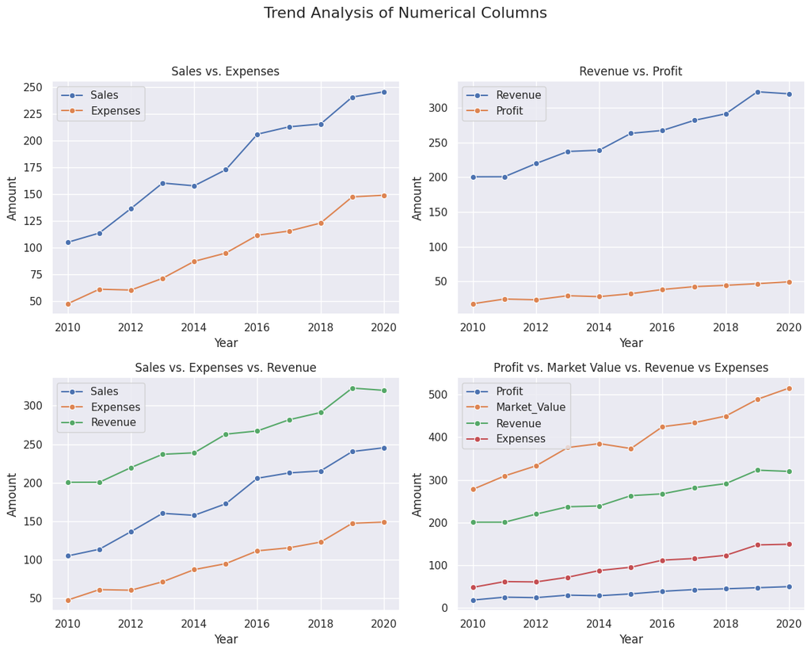

```python
# Define the columns to plot

columns_to_plot_2 = [['Sales', 'Expenses'], ['Revenue', 'Profit'], ['Sales', 'Expenses', 'Revenue'], ['Profit', 'Market_Value', 'Revenue', 'Expenses']]
titles = ['Sales vs. Expenses', 'Revenue vs. Profit', 'Sales vs. Expenses vs. Revenue', 'Profit vs. Market Value vs. Revenue vs Expenses']
axes_positions = [(0, 0), (0, 1), (1, 0), (1, 1)]

# Define the figure and axes

fig, axes = plt.subplots(2, 2, figsize=(12, 10))
fig.suptitle('Trend Analysis of Numerical Columns', fontsize=16)

# Iterate through the subplots and plot the corresponding columns

for i, cols in enumerate(columns_to_plot_2):
    ax = axes[axes_positions[i][0], axes_positions[i][1]] #get the axis
    for col in cols:
        sns.lineplot(x='Year', y=col, data=df, ax=ax, label=col, marker='o')
    ax.set_title(titles[i])
    ax.set_xlabel('Year')
    ax.set_ylabel('Amount')
    ax.legend()
    ax.grid(True)

# Adjust layout for better spacing

plt.tight_layout(rect=[0, 0.03, 1, 0.95])

# Show the plots

plt.show()
```

# 4. How to interpret line chart

Key Features to Look For

Shape/Trend:

- Overall Direction: Is the line generally going upwards (positive trend), downwards (negative trend), or staying relatively flat (no trend)?
- Linearity: Is the change happening at a constant rate (straight line), or is it curving?
- Rate of Change: Is the line steep (rapid change) or gradual (slow change)? Look for sections where the line is steeper or flatter.
- Patterns: Are there any repeating patterns, such as cycles or seasonality?

Center:

- While line charts don't have a median like box plots, you can look at the average level of the data over the period shown. This gives you a sense of the typical value.

Spread/Variability:

- Line charts show the range of values over time. A large vertical distance between the highest and lowest points on the line indicates high variability.
- Look for periods where the line is more volatile (lots of up-and-down movement) or more stable (less movement).

Outliers:

- Points that are significantly higher or lower than the general trend can be considered potential outliers. These may indicate unusual events or errors in the data.

Gaps:

- Gaps in the line indicate missing data for those periods. Consider why the data might be missing and whether it affects your interpretation.

Correlation (when comparing multiple lines):

- If you have multiple lines on the same chart, consider how they relate to each other. Do they move in the same direction (positive correlation), opposite directions (negative correlation), or independently?

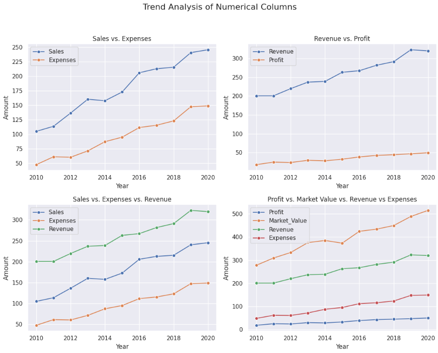

Top Left Chart

Top Right Chart

Shape/Trend:

- Overall Direction: Positive trend.
- Linearity: Somewhat linear.
- Rate of Change: Fairly consistent rise.
- Patterns: No obvious repeating patterns.
- Center: Average value is in the middle of the y-axis.
- Spread/Variability: Moderate variability.
- Outliers: No obvious outliers.
- Gaps: No gaps.

Bottom Left Chart

Shape/Trend:

- Overall Direction: Positive trend.
- Linearity: Somewhat linear.
- Rate of Change: Mostly consistent rise.
- Patterns: No obvious repeating patterns
- Center: Average value is in the middle.
- Spread/Variability: Low variability.
- Outliers: No outliers.
- Gaps: No gaps.

Bottom Right Chart

Shape/Trend:

- Overall Direction: Positive trend.
- Linearity: Somewhat linear.
- Rate of Change: Mostly consistent rise.
- Patterns: No obvious repeating patterns
- Center: Average value is in the middle.
- Spread/Variability: Low variability.
- Outliers: No outliers.
- Gaps: No gaps.